# Course Project Report: Practical Machine Learning

Charles E.

September 17, 2015

## Executive Summary

Jawbone Up, Nike FuelBand, and Fitbit are examples of Human Activity Recognition (HAR) wearable devices that capture data about personal activity and movement. Individuals use the data from HAR devices for a variety of purposes such as identifying sleep patterns, tracking activity and weight loss, and monitoring personal exercise goals. The devises are part of a “quantified self” movement that has grown in popularity as the affordability, storage capacity, and interactivity of these devices have improved.

While these devices are useful to quantify how much an individual performs a particular activity they generally don’t quantify how well it was performed.

This intent of this project was to predict the manner (‘classe’ variable) in which an individual completed an exercise based on data from accelerometers on the belt, forearm, arm, and dumbbell of 6 participants.

Each subject was asked to perform barbell lifts in 5 different ways using both correct and incorrect form.  
This report describes how the model was built, how cross validation was used, and describes the expected out of sample error.

Training and Test data sets were used to develop and test the model. Both data exhibited a large number missing observations (NA, blanks) for the many of the variables.

Of the original 160 variables 52 were retained and used in both the Training and Test data as were all rows. Subject names were removed from both data sets. Remaining (predictor) variables were numeric with the exception of the (dependent) ‘classe’ factor variable. The model attempts to predict the following ‘classe’ levels based on a subject’s accelerometer data: - A = Exactly according to the specification - B = Throwing the elbows to the front - C = Lifting the dumbbell only halfway - D = Lowering the dumbbell only halfway - E = Throwing the hips to the front

The Training data was sliced into a Training subset **75%** and Quiz subset **25%**. The model used a Random Forest function developed using the Training data and tuned on the Quiz data. The model was used on the Test data set one time and was able to predict 20 different test cases with 100% accuracy.

## 1. Preparing Data

### Load Packages

```r
 suppressPackageStartupMessages(library(caret))
 suppressPackageStartupMessages(library(corrplot))
 suppressPackageStartupMessages(library(randomForest))
 suppressPackageStartupMessages(library(e1071))
 suppressPackageStartupMessages(library(rpart))
 suppressPackageStartupMessages(library(rpart.plot))
```

### Download the Data

```r
urltrain <-"https://d396qusza40orc.cloudfront.net/predmachlearn/pml-training.csv"
urltest <- "https://d396qusza40orc.cloudfront.net/predmachlearn/pml-testing.csv"

trian <- "./data/pml-training.csv"
test  <- "./data/pml-testing.csv"

if (!file.exists("./data")) {
  dir.create("./data")
}
if (!file.exists(trian)) {
  download.file(urltrain, destfile=trian, method="curl")
}
if (!file.exists(test)) {
  download.file(urltest, destfile=test, method="curl")
}

rawTrain <- read.csv("./data/pml-training.csv", header=T, na.strings = c('NA','#DIV/0!',''))
rawTest <- read.csv("./data/pml-testing.csv", header=T, na.strings = c('NA','#DIV/0!',''))

dim(rawTrain)
dim(rawTest)
```

```
## [1] 19622   160
## [1]  20 160
```

The training data (rawTrain) contains 19622 observations and 160 variables. The test data (rawTrain) contains 20 observations and the same 160 variables.

A review of the data fields indicate that the first the seven variables are dimensional (include name, row, timestamps) will not be relevant to our model. The first seven are removed as are variables with missing data (NA). The last variable is ‘classe’, the variable which the model will attempt to predict. All remaining variables are numeric.

### Clean the data

Columns containing NA are removed from the rawTrain and rawTest data.A the class of all remaining variables except for the last variable (‘classe’) are set to numeric.

```r
rawTrain <- rawTrain[, colSums(is.na(rawTrain)) == 0]
rawTest <- rawTest[, colSums(is.na(rawTest)) == 0]
dim(rawTrain); dim(rawTest)

classe <- rawTrain$classe
trainx <- grepl("^X|timestamp|window", names(rawTrain))
rawTrain <- rawTrain[, !trainx]
trainDf <- rawTrain[, sapply(rawTrain, is.numeric)]
trainDf$classe <- classe

testx <- grepl("^X|timestamp|window", names(rawTest ))
rawTest  <- rawTest [, !testx]
testDf <- rawTest [, sapply(rawTest , is.numeric)]

dim(trainDf); dim(testDf)
```

[output not shown]

### Slice Data: splitting Training Data and Cross-Validation

The training data (trainDT) is split into data sets that will be used for developing and tuning the model; **75%** will be used as the training data (‘train_df’) and **25%** will be used as the initial test data (‘quiz_dt’) for cross validation. The original test data (‘testDt’) will be retained and used once to test the final model.

```r
#seed set for reproducibility
set.seed(1100)

index_train <- createDataPartition(y=trainDf$classe, p=0.75, list=FALSE)
train_df <- trainDf[index_train,]
quiz_dt <- trainDf[-index_train,]
dim(train_df); dim(quiz_dt)
```

[output not shown]

#### Density Plot

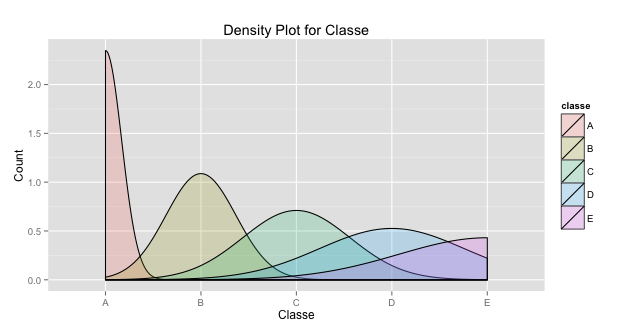

```r
library(ggplot2)

p<-ggplot(data=train_df, aes(classe, fill = classe)) +
  geom_density(alpha = 0.2) +
    labs(title="Density Plot for Classe") +
  labs(x="Classe", y="Count")
p
```

### Predictions Against Cross Validation Data

A Random Forest model was selected and a predictions for each iteration were cross validated using 5-fold cross validation.

```r
rfmod <- train(classe ~ .,
      data = train_df,
      method = 'rf',
      trControl = trainControl(method = "cv",
                  number = 5,
                  allowParallel = TRUE,
                  verboseIter = TRUE))
rfmod
```

```
Random Forest

14718 samples
   52 predictor
    5 classes: 'A', 'B', 'C', 'D', 'E'

No pre-processing
Resampling: Cross-Validated (5 fold)
Summary of sample sizes: 11774, 11774, 11774, 11775, 11775
Resampling results across tuning parameters:

  mtry  Accuracy   Kappa      Accuracy SD   Kappa SD
   2    0.9919827  0.9898569  0.0012385654  0.0015678941
  27    0.9913712  0.9890838  0.0005139012  0.0006512408
  52    0.9831500  0.9786818  0.0009161330  0.0011598030

Accuracy was used to select the optimal model using  the largest value.
The final value used for the model was mtry = 2.
```

### Out of Sample Error

Once the model was developed using the training data (train_df) it was tested on the test data set (quiz_dt). The confusion matrix produced from cross validation data of the model test (rfpred) is provided below.

```r
rfpred <- predict(rfmod,quiz_dt)
rfcmx <- confusionMatrix(rfpred,quiz_dt$classe)
rfcmx
```

```
## Confusion Matrix and Statistics

##          Reference
## Prediction    A    B    C    D    E
##         A 1395    3    0    0    0
##         B    0  946   13    0    0
##         C    0    0  839    9    0
##         D    0    0    3  794    2
##         E    0    0    0    1  899

## Overall Statistics

##               Accuracy : 0.9937
##                 95% CI : (0.991, 0.9957)
##    No Information Rate : 0.2845
##    P-Value [Acc > NIR] : < 2.2e-16

##                  Kappa : 0.992
## Mcnemar's Test P-Value : NA

## Statistics by Class:

##                     Class: A Class: B Class: C Class: D Class: E
## Sensitivity            1.0000   0.9968   0.9813   0.9876   0.9978
## Specificity            0.9991   0.9967   0.9978   0.9988   0.9998
## Pos Pred Value         0.9979   0.9864   0.9894   0.9937   0.9989
## Neg Pred Value         1.0000   0.9992   0.9961   0.9976   0.9995
## Prevalence             0.2845   0.1935   0.1743   0.1639   0.1837
## Detection Rate         0.2845   0.1929   0.1711   0.1619   0.1833
## Detection Prevalence   0.2851   0.1956   0.1729   0.1629   0.1835
## Balanced Accuracy      0.9996   0.9968   0.9895   0.9932   0.9988
```

The confusion matrix indicates that the model’s accuracy was 99.4% and we can expect accuracy between 99.1% and 99.6% with 95% confidence. The **out of sample error** for this model is .0063. The calculation for the out of sample error is 1-accuracy (.9937) for predictions based on the cross validation data (quiz_dt).

#### Plotting Accuracy of Predictions

The plot below illustrates the accuracy of the model by comparing the predicted and actual values. The heavy bar at the intersection of all five classe categories indicates that the amount of correct predictions is high. This suggests that the accuracy of the model is consistent across categories.

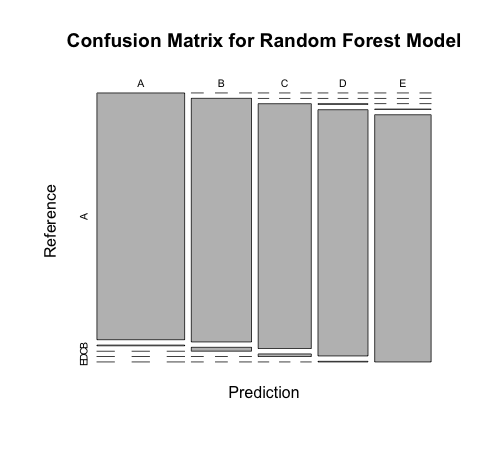

```r
p2<-plot(rfcmx[[2]], main="Confusion Matrix for Random Forest Model")
p2
```

These combinations of factors suggest that the model will perform with an accuracy rate above 99% when applied to the reserved test data (testDf). This means we can be confident that the model will correctly categorize all 20 test cases.

### Applying the Model to the Final Test Set

Once the Random Forest model (rfmod) has been developed and cross validated it is applied to the test data (testDt) for the first time. To test the accuracy of the model the model will have to correctly predict the classe of 20 sample cases.

```r
#coltestDf <- length(colnames(testDf[ ]))
#colnames(testDf)[coltestDf] <- 'classe'

test_rf <- predict(rfmod,testDf)
test_rf
```

The model correctly predicted all 20 test records from the final test data test.

[output not shown]

### Process Answer Files

The predicted classification of the 20 sample cases are printed to the working directory for final submission.

```r
answers <- predict(rfmod,testDf)

pml_write_files = function(x){
  n = length(x)
  for(i in 1:n){
    filename = paste0("problem_id_",i,".txt")
    write.table(x[i],file=filename,quote=FALSE,row.names=FALSE,col.names=FALSE)
  }
}

pml_write_files(answers)
```

### References and Resources

More information about the data (the Weight Lifting Exercise Data set) here: http://groupware.les.inf.puc-rio.br/har

The training data for this project are available here: https://d396qusza40orc.cloudfront.net/predmachlearn/pml-training.csv

The test data are available here: https://d396qusza40orc.cloudfront.net/predmachlearn/pml-testing.csv